# **FordGoBike-Trip Data Exploration**

## by **Subrat Kumar Singh**

## Preliminary Wrangling

```python
# import all packages and set plots to be embedded inline
import numpy as np
import pandas as pd
import matplotlib.pyplot as plt
import seaborn as sb

%matplotlib inline
```

```python
#lets load the Feb-2019 Fordgobike dataset
df = pd.read_csv('201902-fordgobike-tripdata.csv')
df.head()
```

|  | duration_sec | start_time | end_time | start_station_id | start_station_name | start_station_latitude | start_station_longitude | end_station_id | end_station_name | end_station_latitude | end_station_longitude | bike_id | user_type | member_birth_year | member_gender | bike_share_for_all_trip |
| --- | --- | --- | --- | --- | --- | --- | --- | --- | --- | --- | --- | --- | --- | --- | --- | --- |
| 0 | 52185 | 2019-02-28 17:32:10.1450 | 2019-03-01 08:01:55.9750 | 21.0 | Montgomery St BART Station (Market St at 2nd St) | 37.789625 | -122.400811 | 13.0 | Commercial St at Montgomery St | 37.794231 | -122.402923 | 4902 | Customer | 1984.0 | Male | No |
| 1 | 42521 | 2019-02-28 18:53:21.7890 | 2019-03-01 06:42:03.0560 | 23.0 | The Embarcadero at Steuart St | 37.791464 | -122.391034 | 81.0 | Berry St at 4th St | 37.775880 | -122.393170 | 2535 | Customer | NaN | NaN | No |
| 2 | 61854 | 2019-02-28 12:13:13.2180 | 2019-03-01 05:24:08.1460 | 86.0 | Market St at Dolores St | 37.769305 | -122.426826 | 3.0 | Powell St BART Station (Market St at 4th St) | 37.786375 | -122.404904 | 5905 | Customer | 1972.0 | Male | No |
| 3 | 36490 | 2019-02-28 17:54:26.0100 | 2019-03-01 04:02:36.8420 | 375.0 | Grove St at Masonic Ave | 37.774836 | -122.446546 | 70.0 | Central Ave at Fell St | 37.773311 | -122.444293 | 6638 | Subscriber | 1989.0 | Other | No |
| 4 | 1585 | 2019-02-28 23:54:18.5490 | 2019-03-01 00:20:44.0740 | 7.0 | Frank H Ogawa Plaza | 37.804562 | -122.271738 | 222.0 | 10th Ave at E 15th St | 37.792714 | -122.248780 | 4898 | Subscriber | 1974.0 | Male | Yes |

```python
#let see the number of rows and columns in dataset
df.shape
```

```
(183412, 16)
```

```python
#let see the info of the dataset along with the count of non null values in each columns
df.info()
```

```
<class 'pandas.DataFrame'>
RangeIndex: 183412 entries, 0 to 183411
Data columns (total 16 columns):
 #   Column                   Non-Null Count   Dtype
---  ------                   --------------   -----
 0   duration_sec             183412 non-null  int64
 1   start_time               183412 non-null  str
 2   end_time                 183412 non-null  str
 3   start_station_id         183215 non-null  float64
 4   start_station_name       183215 non-null  str
 5   start_station_latitude   183412 non-null  float64
 6   start_station_longitude  183412 non-null  float64
 7   end_station_id           183215 non-null  float64
 8   end_station_name         183215 non-null  str
 9   end_station_latitude     183412 non-null  float64
 10  end_station_longitude    183412 non-null  float64
 11  bike_id                  183412 non-null  int64
 12  user_type                183412 non-null  str
 13  member_birth_year        175147 non-null  float64
 14  member_gender            175147 non-null  str
 15  bike_share_for_all_trip  183412 non-null  str
dtypes: float64(7), int64(2), str(7)
memory usage: 22.4 MB
```

```python
#let look on the statistical computation of the dataset like, mean, median, mode etc
df.describe()
```

|  | duration_sec | start_station_id | start_station_latitude | start_station_longitude | end_station_id | end_station_latitude | end_station_longitude | bike_id | member_birth_year |
| --- | --- | --- | --- | --- | --- | --- | --- | --- | --- |
| count | 183412.000000 | 183215.000000 | 183412.000000 | 183412.000000 | 183215.000000 | 183412.000000 | 183412.000000 | 183412.000000 | 175147.000000 |
| mean | 726.078435 | 138.590427 | 37.771223 | -122.352664 | 136.249123 | 37.771427 | -122.352250 | 4472.906375 | 1984.806437 |
| std | 1794.389780 | 111.778864 | 0.099581 | 0.117097 | 111.515131 | 0.099490 | 0.116673 | 1664.383394 | 10.116689 |
| min | 61.000000 | 3.000000 | 37.317298 | -122.453704 | 3.000000 | 37.317298 | -122.453704 | 11.000000 | 1878.000000 |
| 25% | 325.000000 | 47.000000 | 37.770083 | -122.412408 | 44.000000 | 37.770407 | -122.411726 | 3777.000000 | 1980.000000 |
| 50% | 514.000000 | 104.000000 | 37.780760 | -122.398285 | 100.000000 | 37.781010 | -122.398279 | 4958.000000 | 1987.000000 |
| 75% | 796.000000 | 239.000000 | 37.797280 | -122.286533 | 235.000000 | 37.797320 | -122.288045 | 5502.000000 | 1992.000000 |
| max | 85444.000000 | 398.000000 | 37.880222 | -121.874119 | 398.000000 | 37.880222 | -121.874119 | 6645.000000 | 2001.000000 |

```python
#convert the start_time and end_time to date_time type
df['start_time'] = pd.to_datetime(df['start_time'])
df['end_time'] = pd.to_datetime(df['end_time'])
df.info()
```

```
<class 'pandas.DataFrame'>
RangeIndex: 183412 entries, 0 to 183411
Data columns (total 16 columns):
 #   Column                   Non-Null Count   Dtype
---  ------                   --------------   -----
 0   duration_sec             183412 non-null  int64
 1   start_time               183412 non-null  datetime64[us]
 2   end_time                 183412 non-null  datetime64[us]
 3   start_station_id         183215 non-null  float64
 4   start_station_name       183215 non-null  str
 5   start_station_latitude   183412 non-null  float64
 6   start_station_longitude  183412 non-null  float64
 7   end_station_id           183215 non-null  float64
 8   end_station_name         183215 non-null  str
 9   end_station_latitude     183412 non-null  float64
 10  end_station_longitude    183412 non-null  float64
 11  bike_id                  183412 non-null  int64
 12  user_type                183412 non-null  str
 13  member_birth_year        175147 non-null  float64
 14  member_gender            175147 non-null  str
 15  bike_share_for_all_trip  183412 non-null  str
dtypes: datetime64[us](2), float64(7), int64(2), str(5)
memory usage: 22.4 MB
```

```python
#lets create the age columns from the member birth year
df['age'] = 2019 - df['member_birth_year']
df.head()
```

|  | duration_sec | start_time | end_time | start_station_id | start_station_name | start_station_latitude | start_station_longitude | end_station_id | end_station_name | end_station_latitude | end_station_longitude | bike_id | user_type | member_birth_year | member_gender | bike_share_for_all_trip | age |
| --- | --- | --- | --- | --- | --- | --- | --- | --- | --- | --- | --- | --- | --- | --- | --- | --- | --- |
| 0 | 52185 | 2019-02-28 17:32:10.145 | 2019-03-01 08:01:55.975 | 21.0 | Montgomery St BART Station (Market St at 2nd St) | 37.789625 | -122.400811 | 13.0 | Commercial St at Montgomery St | 37.794231 | -122.402923 | 4902 | Customer | 1984.0 | Male | No | 35.0 |
| 1 | 42521 | 2019-02-28 18:53:21.789 | 2019-03-01 06:42:03.056 | 23.0 | The Embarcadero at Steuart St | 37.791464 | -122.391034 | 81.0 | Berry St at 4th St | 37.775880 | -122.393170 | 2535 | Customer | NaN | NaN | No | NaN |
| 2 | 61854 | 2019-02-28 12:13:13.218 | 2019-03-01 05:24:08.146 | 86.0 | Market St at Dolores St | 37.769305 | -122.426826 | 3.0 | Powell St BART Station (Market St at 4th St) | 37.786375 | -122.404904 | 5905 | Customer | 1972.0 | Male | No | 47.0 |
| 3 | 36490 | 2019-02-28 17:54:26.010 | 2019-03-01 04:02:36.842 | 375.0 | Grove St at Masonic Ave | 37.774836 | -122.446546 | 70.0 | Central Ave at Fell St | 37.773311 | -122.444293 | 6638 | Subscriber | 1989.0 | Other | No | 30.0 |
| 4 | 1585 | 2019-02-28 23:54:18.549 | 2019-03-01 00:20:44.074 | 7.0 | Frank H Ogawa Plaza | 37.804562 | -122.271738 | 222.0 | 10th Ave at E 15th St | 37.792714 | -122.248780 | 4898 | Subscriber | 1974.0 | Male | Yes | 45.0 |

```python
#lets check for the missing values in each columns
df.isnull().any()
```

```
duration_sec               False
start_time                 False
end_time                   False
start_station_id            True
start_station_name          True
start_station_latitude     False
start_station_longitude    False
end_station_id              True
end_station_name            True
end_station_latitude       False
end_station_longitude      False
bike_id                    False
user_type                  False
member_birth_year           True
member_gender               True
bike_share_for_all_trip    False
age                         True
dtype: bool
```

```python
#will select some target columns according to our area of interest/exploration
target_col = [
    'duration_sec',
    'start_time',
    'end_time',
    'start_station_name',
    'end_station_name',
    'user_type',
    'member_birth_year',
    'member_gender',
    'age'
]
new_df = df[target_col]
new_df.head()
```

|  | duration_sec | start_time | end_time | start_station_name | end_station_name | user_type | member_birth_year | member_gender | age |
| --- | --- | --- | --- | --- | --- | --- | --- | --- | --- |
| 0 | 52185 | 2019-02-28 17:32:10.145 | 2019-03-01 08:01:55.975 | Montgomery St BART Station (Market St at 2nd St) | Commercial St at Montgomery St | Customer | 1984.0 | Male | 35.0 |
| 1 | 42521 | 2019-02-28 18:53:21.789 | 2019-03-01 06:42:03.056 | The Embarcadero at Steuart St | Berry St at 4th St | Customer | NaN | NaN | NaN |
| 2 | 61854 | 2019-02-28 12:13:13.218 | 2019-03-01 05:24:08.146 | Market St at Dolores St | Powell St BART Station (Market St at 4th St) | Customer | 1972.0 | Male | 47.0 |
| 3 | 36490 | 2019-02-28 17:54:26.010 | 2019-03-01 04:02:36.842 | Grove St at Masonic Ave | Central Ave at Fell St | Subscriber | 1989.0 | Other | 30.0 |
| 4 | 1585 | 2019-02-28 23:54:18.549 | 2019-03-01 00:20:44.074 | Frank H Ogawa Plaza | 10th Ave at E 15th St | Subscriber | 1974.0 | Male | 45.0 |

```python
#now we will again check for the missing values in our targeted columns
print(new_df.isnull().any())
print(new_df.isnull().sum())
```

```
duration_sec          False
start_time            False
end_time              False
start_station_name     True
end_station_name       True
user_type             False
member_birth_year      True
member_gender          True
age                    True
dtype: bool
duration_sec             0
start_time               0
end_time                 0
start_station_name     197
end_station_name       197
user_type                0
member_birth_year     8265
member_gender         8265
age                   8265
dtype: int64
```

```python
#now we will remove this missing values from respective columns
new_df.dropna(subset=[
    'start_station_name',
    'end_station_name',
    'member_birth_year',
    'member_gender',
    'age'
], inplace=True)
print(new_df.isnull().sum())
print(len(new_df))
print(len(df))
```

```
duration_sec          0
start_time            0
end_time              0
start_station_name    0
end_station_name      0
user_type             0
member_birth_year     0
member_gender         0
age                   0
dtype: int64
174952
183412
```

### What is the structure of your dataset?

There are 183412 records in the dataset with 16 features/columns duration_sec, start_time, end_time, start_station_id, start_station_name, start_station_longitude, start_station_latitude, end_station_name, end_station_latitude, end_station_longitude, bike_id, user_type, member_birth_year, member_gender, now there are 174952 records after handling the missing values

### What is/are the main feature(s) of interest in your dataset?

I'm interested in looking how trip duration(duration_sec) dependent on user type, start station, end station, member gender, age

### What features in the dataset do you think will help support your investigation into your feature(s) of interest?

I think the trip duration(duration_sec) feature of dataset will support my investigation on features like start_station, end_station, gender, age, and user_type can support my investigation

## Univariate Exploration

### Ques:1 Which type of users use the bike sharing system most?

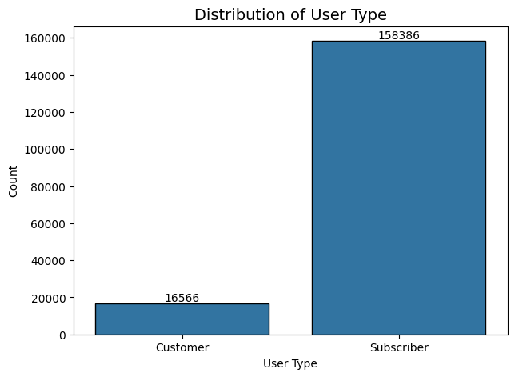

```python
#plotting the user type distribution using the countplot
plt.figure(figsize=(7,5))

sb.countplot(data=new_df, x='user_type', edgecolor='black')
plt.title('Distribution of User Type', fontsize=14)
plt.xlabel('User Type')
plt.ylabel('Count')

ax = plt.gca()
for container in ax.containers :
    ax.bar_label(container)

plt.show()
```

**Observation**

- Most of the riders are Subsribers than Customers
- Riders are the regular customers who have became the permanent Subscribers

### Ques:2 Which type of gender use the bike sharing system most?

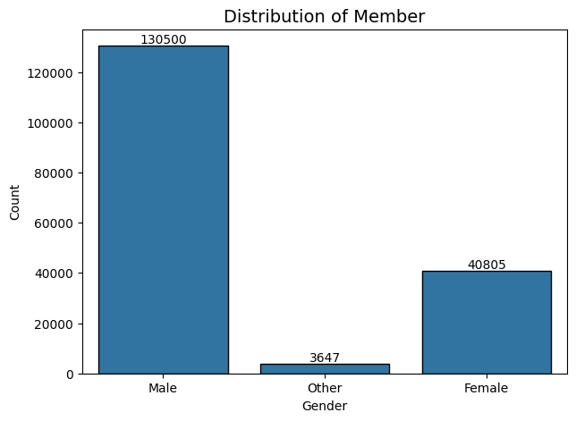

```python
#plotting the gender distribution using the countplot
plt.figure(figsize=(7,5))

sb.countplot(data=new_df, x='member_gender', edgecolor='black')
plt.title('Distribution of Member', fontsize=14)
plt.xlabel('Gender')
plt.ylabel('Count')

ax = plt.gca()
for container in ax.containers :
    ax.bar_label(container)

plt.show()
```

**Observation**

- Male riders dominate the dataset
- Female riders are comparetively fewer
- The other category has shown very few number of representation
- This shows the gender imbalance in the dataset

### Quest3: How are trip durations distributed among users?

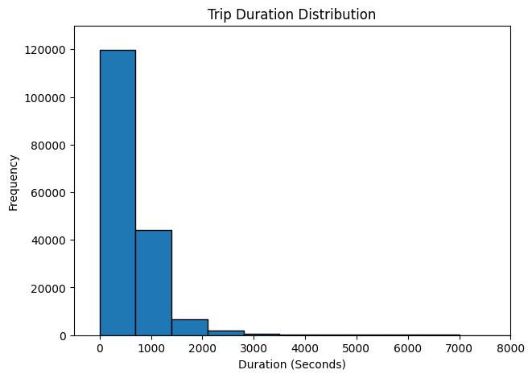

```python
#We will show the distribution of the trip duration
plt.figure(figsize=(7,5))

#need to explicitly define the the bins range
bin_size=700
bins = np.arange(0, df['duration_sec'].max()+bin_size, bin_size)
plt.hist(new_df['duration_sec'], bins=bins, edgecolor='black')

# adding title and labels
plt.title('Trip Duration Distribution')
plt.xlabel('Duration (Seconds)')
plt.ylabel('Frequency')
plt.axis([-500,8000, 0, 130000])
plt.show()
```

**Observation**

- Most trips are short-duration rides i.e [0-700 sec]
- Distribution is heavily right-skewed.
- Few trips have extremely long durations.

### Ques:4 Which age group uses the bike share system most?

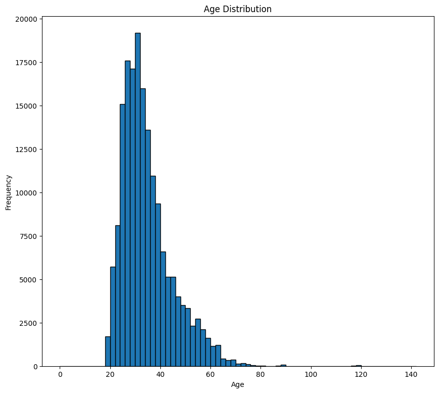

```python
#showing the age distribution with histogram
plt.figure(figsize=(10,9))

bin_size = 2
bins = np.arange(0, new_df['age'].max()+bin_size, bin_size)
plt.hist(new_df['age'], bins=bins, edgecolor='black')
plt.xlabel('Age')
plt.ylabel('Frequency')
plt.title('Age Distribution')

plt.show()
```

**Observation**

- Most riders are from 20-60 age groups
- Young riders shows the more number of rides
- Other age group shows the less number of contribution

### Ques:5 Which start stations are frequently used?

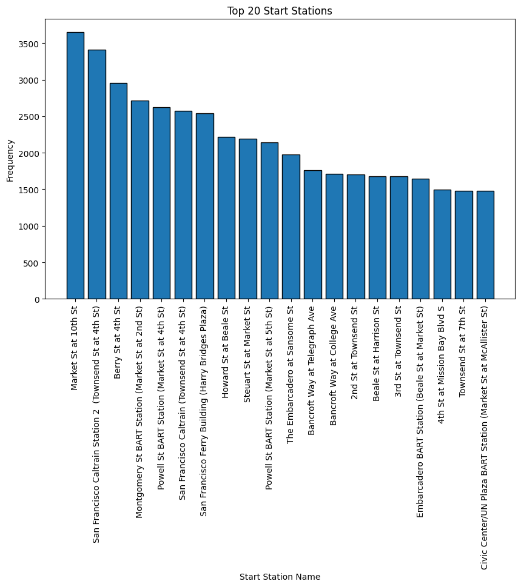

```python
#bar plot showing which start stations has most number of visitors, top 20 start stations
top_start_station = new_df['start_station_name'].value_counts().head(20)

plt.figure(figsize=(10,6))

plt.bar(top_start_station.index, top_start_station.values, edgecolor='black')
plt.xlabel('Start Station Name')
plt.ylabel('Frequency')
plt.title('Top 20 Start Stations')
plt.xticks(rotation=90)

plt.show()
```

**Observations**

- Some stations have significantly more popular than others
- High use stations represent crowded on central areas

### Ques:6 Which end stations are frequently used?

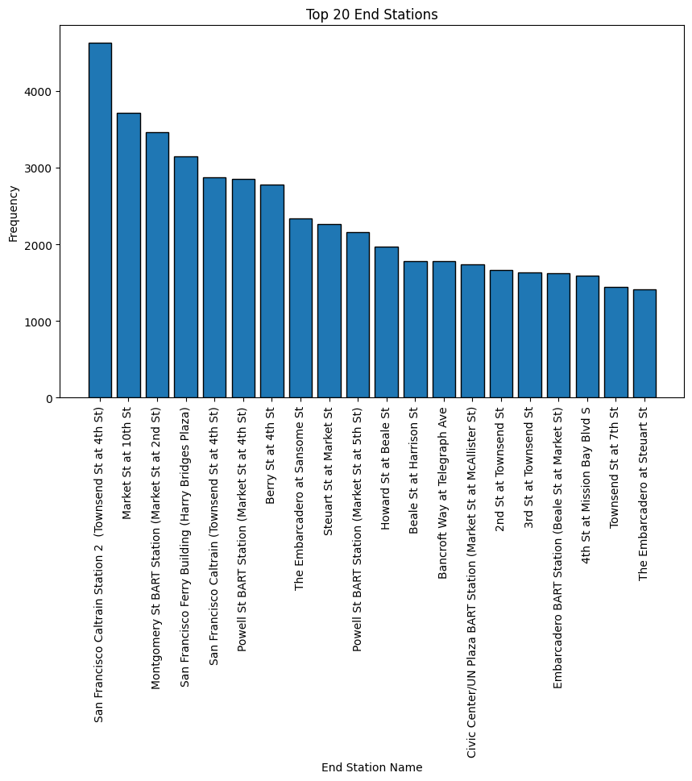

```python
#bar plot showing which end stations has most number of visitors, top 20 end stations
top_end_station = new_df['end_station_name'].value_counts().head(20)

plt.figure(figsize=(10,6))

plt.bar(top_end_station.index, top_end_station.values, edgecolor='black')
plt.xlabel('End Station Name')
plt.ylabel('Frequency')
plt.title('Top 20 End Stations')
plt.xticks(rotation=90)

plt.show()
```

**Observations**

- Some stations are highly used by the riders for departing
- These stations are overly crowded places
- Some stations experienced few number of riders

### Discuss the distribution(s) of your variable(s) of interest. Were there any unusual points? Did you need to perform any transformations?

#### **Of the features you investigated, were there any unusual distributions? Did you perform any operations on the data to tidy, adjust, or change the form of the data? If so, why did you do this?**

Birth year was transformed into age for easier demographic analysis and interpretation. In addition, np.arange() was used in histogram bins to create cleaner and more readable visualizations.

## Bivariate Exploration

### **1. Age vs Trip Duration**

Question: Does age affect the trip duration?

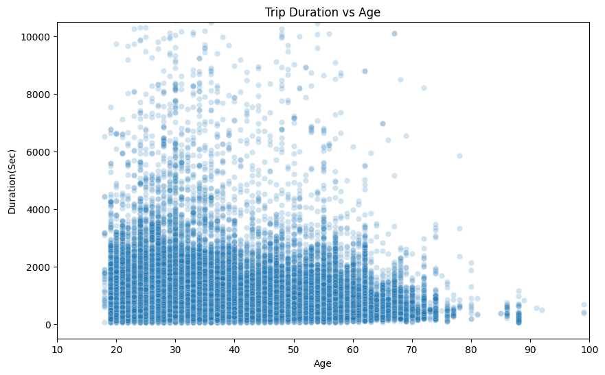

```python
#plotting the age vs trip duration using scatterplot
plt.figure(figsize=(10,6))

sb.scatterplot(data=new_df, x='age', y='duration_sec', alpha=0.2)
plt.xlabel('Age')
plt.ylabel('Duration(Sec)')
plt.title('Trip Duration vs Age')
plt.axis([10,100, -500, 10500])

plt.show()
```

**Observation**

- Most riders are between the ages of 20–40, showing that younger adults use the bike service more frequently.
- Younger riders tend to have longer trip durations, while older riders generally take shorter trips.
- The relationship between age and trip duration is weakly negative, as long-duration trips decrease with increasing age.

### **2. User Type vs Trip Duration**

Question: Does user type affect the trip duration?

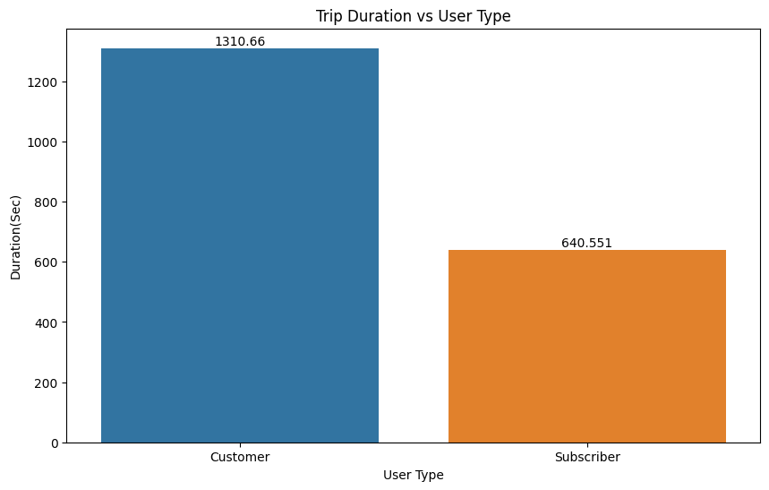

```python
# calculating average trip duration by user type
avg_duration = new_df.groupby('user_type')['duration_sec'].mean().reset_index()
plt.figure(figsize=(10,6))

sb.barplot(data=avg_duration, x='user_type', y='duration_sec', hue='user_type')
plt.xlabel('User Type')
plt.ylabel('Duration(Sec)')
plt.title('Trip Duration vs User Type')

ax = plt.gca()
for container in ax.containers :
    ax.bar_label(container)

plt.show()
```

**Observation**

- The plot shows the average trip duration for each user type.
- Customers have a higher average trip duration compared to Subscribers.
- This indicates that Customers generally take longer trips, while Subscribers tend to take shorter rides.

### **3. Gender vs Trip Duration**

Does trip duration vary across genders?

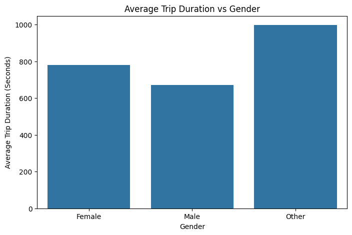

```python
# calculating average trip duration by gender
avg_gender_duration = new_df.groupby('member_gender')['duration_sec'].mean().reset_index()
# plotting clustered bar chart
plt.figure(figsize=(8,5))
sb.barplot(data=avg_gender_duration, x='member_gender', y='duration_sec')
plt.title('Average Trip Duration vs Gender')
plt.xlabel('Gender')
plt.ylabel('Average Trip Duration (Seconds)')

plt.show()
```

### **4. Start Station vs Trip Duration**

Does trip duration vary across different Start Stations?

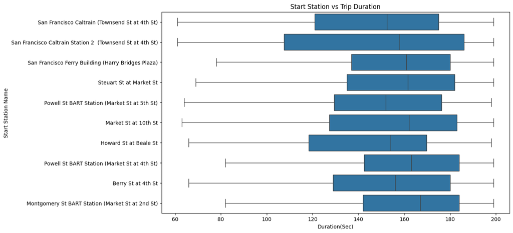

```python
#selecting top 10 start stations
top_start = new_df['start_station_name'].value_counts().head(10).index
#now filtering the dataset
start_df = new_df[new_df['start_station_name'].isin(top_start)]

Q1 = start_df['duration_sec'].quantile(0.25)
Q3 = start_df['duration_sec'].quantile(0.75)
IQR = Q3 - Q1

lower = Q1 - 1.5 * IQR
upper = Q3 - 1.5 * IQR

start_df = start_df[(start_df['duration_sec']>=lower) & (start_df['duration_sec']<=upper)]
start_df

plt.figure(figsize=(12,7))
sb.boxplot(data=start_df, x='duration_sec', y='start_station_name', showfliers=False)
plt.xlabel('Duration(Sec)')
plt.ylabel('Start Station Name')
plt.title('Start Station vs Trip Duration')

plt.show()
```

**Observation**

- Trip Durations are fairly consistent among all the trip durations
- Some start stations have high median trip durations

### **5. End Station vs Trip Duration**

Does trip duration vary across different End Stations?

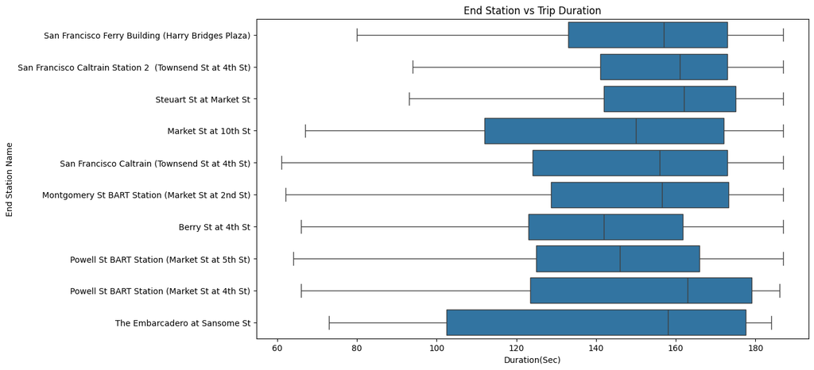

```python
#selecting top 10 end stations
top_end = new_df['end_station_name'].value_counts().head(10).index
#now filtering the dataset
end_df = new_df[new_df['end_station_name'].isin(top_end)]

Q1 = end_df['duration_sec'].quantile(0.25)
Q3 = end_df['duration_sec'].quantile(0.75)
IQR = Q3 - Q1

lower = Q1 - 1.5 * IQR
upper = Q3 - 1.5 * IQR

end_df = end_df[(end_df['duration_sec']>=lower) & (end_df['duration_sec']<=upper)]
end_df

plt.figure(figsize=(12,7))
sb.boxplot(data=end_df, x='duration_sec', y='end_station_name', showfliers=False)
plt.xlabel('Duration(Sec)')
plt.ylabel('End Station Name')
plt.title('End Station vs Trip Duration')

plt.show()
```

**Observation**

- Trip durations are similar to the end stations making in consistent among the riders.
- Certain end stations recieve the long durations compared to other stations

### Did you observe any interesting relationships between the other features (not the main feature(s) of interest)?

Looking upon the average trip duration for each gender strangely other category group have highest trip duration, means people either dont want to disclose their gender, or any other reason

## Multivariate Exploration

### **1. Age vs Trip Duration by User Type**

How does trip duration vary for different age across various user types

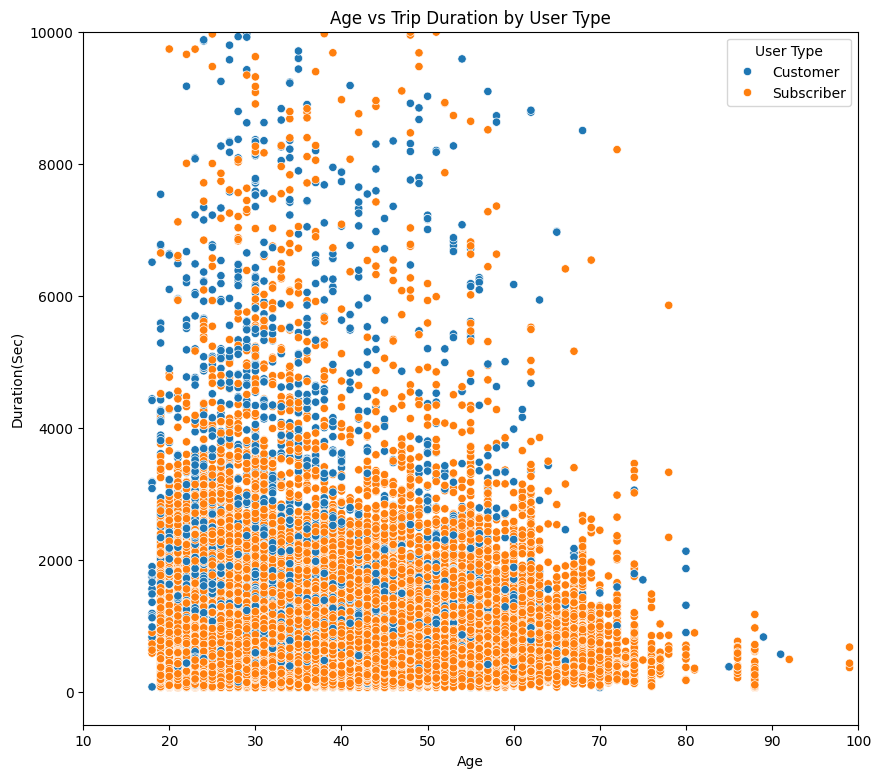

```python
plt.figure(figsize=(10,9))

sb.scatterplot(data=new_df, x='age', y='duration_sec', hue='user_type')
plt.xlabel('Age')
plt.ylabel('Duration(Sec)')
plt.legend(title='User Type')
plt.title('Age vs Trip Duration by User Type')
plt.axis([10,100, -500, 10000])

plt.show()
```

**Observation**

- Customers generally shows the longer duration compare to the subscriber
- Most rider are concerntrated at lower duration regardless of age

### **2. Gender vs Trip Duration by User Age**

How does trip duration vary for gender across and age together?

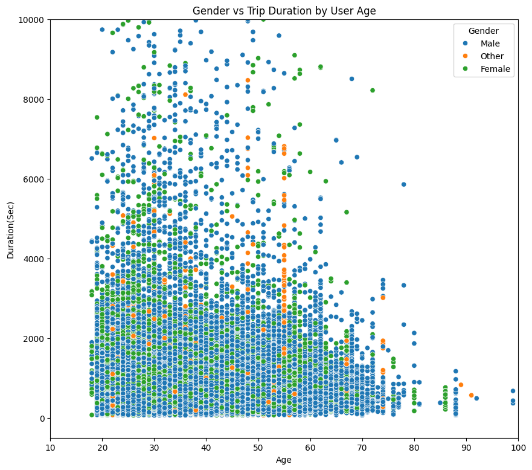

```python
plt.figure(figsize=(10,9))

sb.scatterplot(data=new_df, x='age', y='duration_sec', hue='member_gender')
plt.xlabel('Age')
plt.ylabel('Duration(Sec)')
plt.legend(title='Gender')
plt.title('Gender vs Trip Duration by User Age')
plt.axis([10,100, -500, 10000])

plt.show()
```

### **3. Start Station vs Trip Duration by User ype**

How does trip duration vary for different start stations across across different user type ?

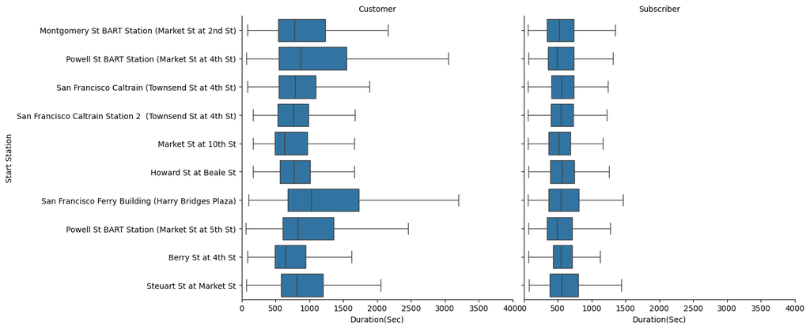

```python
#selecting top 10 start stations
top_start = new_df['start_station_name'].value_counts().head(10).index
#now filtering the dataset
start_df = new_df[new_df['start_station_name'].isin(top_start)]
#creating facet grid plot
g = sb.FacetGrid(start_df, col="user_type", height=6, aspect=1.2)
g.map_dataframe(sb.boxplot, y='start_station_name', x="duration_sec", showfliers=False)
g.set_axis_labels('Duration(Sec)', 'Start Station')
g.set_titles('{col_name}')

plt.xlim(0,4000)
plt.show()
```

**Observations**

- Customers generally shows the longer trips durations across various start stations.
- Subscribers mainly take the shorter rides regarding start stations
- Certain start stations are associated with higher trip durations

### **4. End Station vs Trip Duration by Gender**

How does trip duration vary for different end stations across across different gender ?

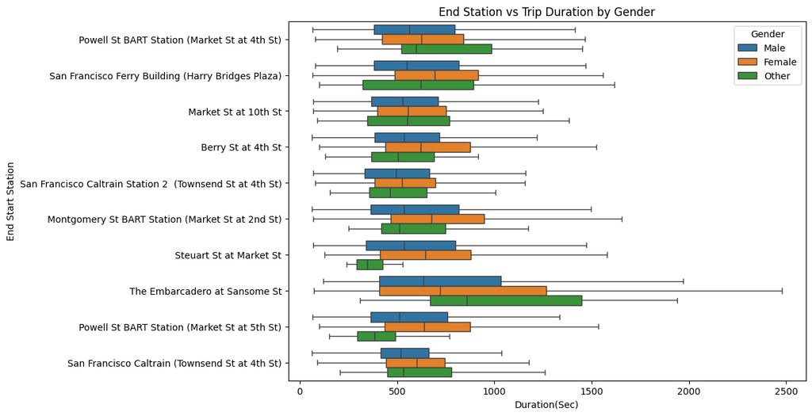

```python
#selecting top 10 end stations
top_end = new_df['end_station_name'].value_counts().head(10).index
#now filtering the dataset
end_df = new_df[new_df['end_station_name'].isin(top_end)]

plt.figure(figsize=(10,7))
sb.boxplot(data=end_df, x='duration_sec', y='end_station_name', hue='member_gender', showfliers=False)
plt.xlabel('Duration(Sec)')
plt.ylabel('End Start Station')
plt.legend(title='Gender')
plt.title('End Station vs Trip Duration by Gender')

plt.show()
```

**Observations**

- Trip Duration remains relatively same across gender and stations
- Certain end stations are associated to longer durations
- Male riders contribute to majority trips across most stations

### Talk about some of the relationships you observed in this part of the investigation. Were there features that strengthened each other in terms of looking at your feature(s) of interest?

Trip durations are influenced by demographic and trip related features. Customers generally took longer rides than Subscribers across different age groups and gender categories. while most riders remains shorter regardless of rider age

## Conclusions

The multivariate analysis further showed that Customers consistently took longer rides across different age groups and gender categories, while Subscribers mainly used the service for shorter commuting trips.

Steps included :

1. Performed Preliminary Wrangling were we load the dataset and look on the top 5 values, identified the datatypes of the columsns according interest of exploration, then performed data cleaning handle the missing values and outliers
2. Next moved to univariate exploration where every features are explored individually for insight and patterns and identified the observations.
3. In bivariate and multivariate exploration every feature is looked upon with the trip duration which helps in understanding the primary relationship between all targeted features with duration_sec(trip duration)